# RHS: Deposit Franchise Value

# 1 Deposit Beta

For periods on or before 2019: branch level deposit beta was estimated using the bank level ‘first stage’ estimated from 2016-2019 rate hike data.  
Estimated as $pred\_int\_exp\_chg\_16\_19/2.5$. Fed funds rate increased by 2.5% during that time.

For periods after 2019: branch level deposit beta was estimated using the bank level ‘first stage’ estimated from 2022-2024 (Used period from Q1 2022 to Q1 2023 to avoid SVB impact, as suggested by PS) rate hike data  
Estimated as $pred\_int\_exp\_chg\_22\_24/4$. Fed funds rate increased by 4% during that time.

Having estimated deposit beta, following [DSS (2024)](https://pages.stern.nyu.edu/~asavov/alexisavov/Alexi_Savov_files/Deposit_Franchise_Valuation.pdf) the deposit franchise value per dollar of deposit is calculated as $(1-\beta)*(1-\frac{1}{(1+0.025)^{10}})$. Note that operating expenses were ignored.

## 1.1 Density of Deposit Frachise Value per Dollar

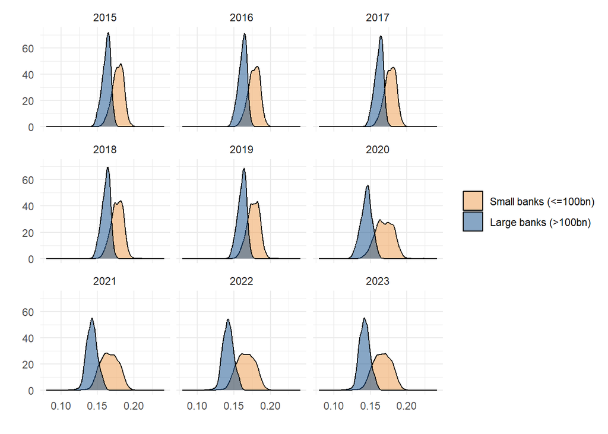

## 1.2 Summary Stats of Deposit Franchise Value per Dollar

```
|yr  |large_bank|mean_df_per_dollar|sd_df_per_dollar|
|----|----------|------------------|----------------|
|2015|0         |0.18              |0.008           |
|2016|0         |0.18              |0.008           |
|2017|0         |0.18              |0.008           |
|2018|0         |0.18              |0.008           |
|2019|0         |0.18              |0.009           |
|2020|0         |0.17              |0.012           |
|2021|0         |0.17              |0.012           |
|2022|0         |0.17              |0.012           |
|2023|0         |0.17              |0.012           |
|2015|1         |0.16              |0.006           |
|2016|1         |0.16              |0.006           |
|2017|1         |0.16              |0.006           |
|2018|1         |0.16              |0.006           |
|2019|1         |0.16              |0.006           |
|2020|1         |0.14              |0.008           |
|2021|1         |0.14              |0.008           |
|2022|1         |0.14              |0.007           |
|2023|1         |0.14              |0.007           |
```

## 1.3 Correlation of Deposit Frachise Value per Dollar

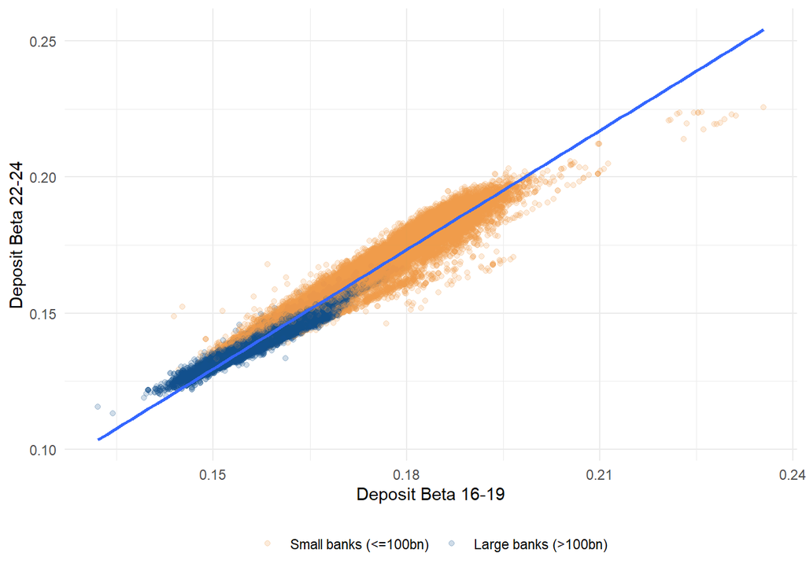

# 2 Sample

Branch-Year Panel, 2015 to 2023.

# 3 Variables

| Variable | Definition |
| --- | --- |
| closed | Takes value 1 if a branch is closed in a given year |
| df_per_dollar | DF factor. Interpretation: franchise value generated by $1 of deposit |
| sophisticated | Takes the value 1 if customers of the branch has above median income, education, and returns with dividend income |
| lag_branch_deposit_amount | branch’s deposit amount in the year before |
| lag_hmda_mtg_amt_gr | County level growth of mortgage originations, lagged by one year |
| lag_cra_loan_amount_amt_lt_1m_gr | County level growth of CRA loan (<1m) originations, lagged by one year |
| lag_county_deposit_hhi | County-level deposit HHI, lagged by one year |
| no_branches_in_zipcode | Number of branches in the same zip code owned by the same bank in the year before |
| establishments_gr | Zip code level growth in establishments from CBP data |
| payroll_gr | Zip code level growth in payroll from CBP data |
| same_zip_prior_3yr_branches | if the branch was acquired by another bank in the previous three years, whether acquiring bank had any branches in the same zip code prior to acquisition |
| legacy_branch | Bank owned this branch three years ago |

# 4 Specification

$$(Closed==1)_{branch,year} = \beta_1 \times (depositbeta)_{branch}$$

$$+ Controls_{branch,year} + BankFE+State\times YearFE+RUCAFE$$
Standard errors clustered at the bank-level (?)

# 5 Regression Results

## 5.1 Full Sample

```
Full Sample
========================================================================================================================================================
                                                                                   Dependent variable:
                                 -----------------------------------------------------------------------------------------------------------------------
                                                                                      Linear Prob.
                                    (1)       (2)       (3)       (4)       (5)       (6)       (7)       (8)       (9)      (10)      (11)      (12)
--------------------------------------------------------------------------------------------------------------------------------------------------------
df_per_dollar                    -0.824*** -1.434*** -0.201**  -1.204*** -1.077*** -1.124*** -0.966*** -0.838*** -1.819***  -0.351*  -0.665*** -0.491***
                                  (0.146)   (0.187)   (0.091)   (0.242)   (0.250)   (0.184)   (0.294)   (0.210)   (0.338)   (0.196)   (0.206)   (0.184)
log(lag_branch_deposit_amount)   -0.022*** -0.029*** -0.018*** -0.015*** -0.018*** -0.019*** -0.021*** -0.021*** -0.037*** -0.026*** -0.023*** -0.019***
                                  (0.001)   (0.002)   (0.001)   (0.001)   (0.002)   (0.002)   (0.003)   (0.003)   (0.005)   (0.003)   (0.003)   (0.002)
lag_hmda_mtg_amt_gr               0.00001   -0.0001   0.00004   0.00004   -0.0001   -0.0001   0.00001  -0.0002**  0.00004   0.00003  -0.00001   0.00002
                                 (0.00003) (0.0001)  (0.00003) (0.0001)  (0.0001)  (0.0001)  (0.0001)  (0.0001)  (0.0001)  (0.0001)  (0.0001)  (0.0001)
lag_cra_loan_amount_amt_lt_1m_gr -0.00000  -0.00001   0.00000   0.00003  -0.00001  -0.0001** -0.00002   0.0001*   0.0001   -0.00004   0.00004   0.00002
                                 (0.00001) (0.0001)  (0.00001) (0.00003) (0.00004) (0.00004) (0.0001)  (0.00004) (0.00005) (0.00004) (0.0001)  (0.0001)
lag_county_deposit_hhi             0.001     0.004    -0.003    -0.003    0.0001     0.004     0.008    -0.006    -0.001    -0.020     0.005   0.025***
                                  (0.003)   (0.006)   (0.003)   (0.007)   (0.009)   (0.008)   (0.007)   (0.005)   (0.010)   (0.013)   (0.009)   (0.009)
log(no_branches_in_zipcode)      -0.039*** -0.037*** -0.043*** -0.071*** -0.072*** -0.062*** -0.051*** -0.037*** -0.040*** -0.016***  -0.002   0.017***
                                  (0.004)   (0.007)   (0.002)   (0.008)   (0.009)   (0.006)   (0.007)   (0.005)   (0.006)   (0.005)   (0.004)   (0.002)
establishments_gr                -0.071*** -0.185*** -0.032*** -0.051*** -0.088*** -0.050**  -0.060*** -0.075*** -0.145*** -0.104*** -0.092*** -0.061**
                                  (0.014)   (0.024)   (0.007)   (0.018)   (0.021)   (0.025)   (0.022)   (0.027)   (0.035)   (0.026)   (0.029)   (0.026)
payroll_gr                       -0.007*** -0.009***  -0.004   -0.011**  -0.022**   -0.006    -0.003   -0.030***  -0.004    -0.002     0.004     0.001
                                  (0.002)   (0.003)   (0.003)   (0.005)   (0.009)   (0.006)   (0.008)   (0.011)   (0.010)   (0.008)   (0.008)   (0.006)
same_zip_prior_3yr_branches      0.100***  0.127***  0.082***  0.084***  0.073***  0.082***  0.092***  0.064***  0.152***  0.105***    0.023     0.059
                                  (0.010)   (0.018)   (0.009)   (0.015)   (0.018)   (0.021)   (0.031)   (0.016)   (0.017)   (0.018)   (0.018)   (0.068)
legacy_branch                    0.020***   0.028**  0.019***   0.008*     0.011   0.017***    0.008   0.015***  0.028***  0.026***    0.001   -0.036***
                                  (0.004)   (0.013)   (0.002)   (0.005)   (0.007)   (0.006)   (0.008)   (0.005)   (0.008)   (0.009)   (0.008)   (0.009)
--------------------------------------------------------------------------------------------------------------------------------------------------------
Sample                             Full      Large     Small     2015      2016      2017      2018      2019      2020      2021      2022      2023
Bank FE                              Y         Y         Y         Y         Y         Y         Y         Y         Y         Y         Y         Y
State*Year FE                        Y         Y         Y         Y         Y         Y         Y         Y         Y         Y         Y         Y
Urban/Rural Areas                    Y         Y         Y         Y         Y         Y         Y         Y         Y         Y         Y         Y
Observations                      666,577   271,943   394,634   84,280    82,205    80,036    77,229    74,772    72,565    67,847    64,838    62,805
R2                                 0.060     0.049     0.079     0.153     0.169     0.126     0.104     0.121     0.109     0.109     0.096     0.074
========================================================================================================================================================
Note:                                                                                                                        *p<0.1; **p<0.05; ***p<0.01
```

## 5.2 Large Bank Sample

```
Large Banks
==========================================================================================================================
                                                                    Dependent variable:
                                 -----------------------------------------------------------------------------------------
                                                                       Linear Prob.
                                    (1)       (2)       (3)       (4)       (5)       (6)       (7)       (8)       (9)
--------------------------------------------------------------------------------------------------------------------------
df_per_dollar                    -1.342*** -1.637*** -1.548*** -2.010*** -1.589*** -3.105***  -0.734*  -1.502*** -0.844***
                                  (0.486)   (0.354)   (0.301)   (0.457)   (0.350)   (0.569)   (0.379)   (0.371)   (0.288)
log(lag_branch_deposit_amount)   -0.014*** -0.022*** -0.024*** -0.031*** -0.032*** -0.053*** -0.034*** -0.034*** -0.026***
                                  (0.003)   (0.003)   (0.004)   (0.004)   (0.005)   (0.011)   (0.005)   (0.006)   (0.005)
lag_hmda_mtg_amt_gr               0.0001    -0.0002  -0.0003*   -0.0001   -0.0002  -0.00001  -0.0003*   0.0001    0.0004
                                 (0.0002)  (0.0003)  (0.0002)  (0.0002)  (0.0002)  (0.0003)  (0.0001)  (0.0002)  (0.0004)
lag_cra_loan_amount_amt_lt_1m_gr -0.00004   0.0001   -0.0002**  -0.0001   0.0002    0.0002   -0.00002   0.0003    -0.0001
                                 (0.0001)  (0.0001)  (0.0001)  (0.0002)  (0.0001)  (0.0002)  (0.0001)  (0.0002)  (0.0002)
lag_county_deposit_hhi             0.008    -0.022     0.001    0.017*     0.001     0.004    -0.037     0.024    0.031*
                                  (0.008)   (0.016)   (0.014)   (0.010)   (0.009)   (0.018)   (0.029)   (0.018)   (0.017)
log(no_branches_in_zipcode)      -0.055*** -0.070*** -0.064*** -0.062*** -0.039*** -0.034***  -0.014     0.004   0.028***
                                  (0.012)   (0.016)   (0.010)   (0.015)   (0.009)   (0.009)   (0.009)   (0.006)   (0.004)
establishments_gr                 -0.035   -0.169***  -0.084   -0.132**  -0.260*** -0.368*** -0.211*** -0.267*** -0.179***
                                  (0.031)   (0.042)   (0.067)   (0.052)   (0.048)   (0.066)   (0.051)   (0.054)   (0.052)
payroll_gr                       -0.017*** -0.035***  -0.005     0.001    -0.042*   -0.011     0.001     0.012    -0.007
                                  (0.005)   (0.012)   (0.009)   (0.014)   (0.021)   (0.015)   (0.015)   (0.014)   (0.009)
same_zip_prior_3yr_branches        0.071    -0.003    0.053**   0.068*    0.087**  0.194***  0.141***    0.013     0.070
                                  (0.044)   (0.038)   (0.023)   (0.034)   (0.036)   (0.016)   (0.019)   (0.016)   (0.116)
legacy_branch                     -0.002    -0.016    -0.003    -0.030     0.018    0.051**   0.045**    0.006   -0.055***
                                  (0.006)   (0.015)   (0.014)   (0.033)   (0.024)   (0.021)   (0.016)   (0.016)   (0.016)
--------------------------------------------------------------------------------------------------------------------------
Sample                             2015      2016      2017      2018      2019      2020      2021      2022      2023
Bank FE                              Y         Y         Y         Y         Y         Y         Y         Y         Y
State*Year FE                        Y         Y         Y         Y         Y         Y         Y         Y         Y
Urban/Rural Areas                    Y         Y         Y         Y         Y         Y         Y         Y         Y
Observations                      34,022    33,676    33,076    31,802    30,628    29,373    27,258    26,427    25,681
R2                                 0.074     0.084     0.066     0.061     0.070     0.074     0.063     0.057     0.031
==========================================================================================================================
Note:                                                                                          *p<0.1; **p<0.05; ***p<0.01
```

## 5.3 Small Bank Sample

```
Small Banks
==========================================================================================================================
                                                                    Dependent variable:
                                 -----------------------------------------------------------------------------------------
                                                                       Linear Prob.
                                    (1)       (2)       (3)       (4)       (5)       (6)       (7)       (8)       (9)
--------------------------------------------------------------------------------------------------------------------------
df_per_dollar                    -0.735*** -0.611**  -0.820***  -0.285    -0.421*  -0.809***  -0.130    -0.135    -0.253
                                  (0.258)   (0.257)   (0.226)   (0.275)   (0.226)   (0.254)   (0.178)   (0.172)   (0.159)
log(lag_branch_deposit_amount)   -0.015*** -0.014*** -0.015*** -0.014*** -0.014*** -0.028*** -0.022*** -0.016*** -0.015***
                                  (0.001)   (0.001)   (0.002)   (0.001)   (0.001)   (0.002)   (0.002)   (0.002)   (0.002)
lag_hmda_mtg_amt_gr               0.00000   -0.0001  -0.00000   0.0001   -0.0002**  0.00003   0.0002*   -0.0001   -0.0001
                                 (0.0001)  (0.0001)  (0.0001)  (0.0001)  (0.0001)  (0.0001)  (0.0001)  (0.0001)  (0.0001)
lag_cra_loan_amount_amt_lt_1m_gr  0.00005  -0.00004  -0.00003   0.00003   0.00003   0.0001   -0.00004  -0.00000   0.0001
                                 (0.00004) (0.00004) (0.00004) (0.00004) (0.00003) (0.00005) (0.00005) (0.00005) (0.00004)
lag_county_deposit_hhi            -0.016*   0.016*     0.004     0.001    -0.009    -0.011    -0.006    -0.012    0.020**
                                  (0.009)   (0.009)   (0.007)   (0.008)   (0.006)   (0.009)   (0.009)   (0.008)   (0.010)
log(no_branches_in_zipcode)      -0.089*** -0.073*** -0.060*** -0.041*** -0.035*** -0.050*** -0.019*** -0.008**  0.008***
                                  (0.007)   (0.006)   (0.006)   (0.004)   (0.005)   (0.006)   (0.005)   (0.003)   (0.002)
establishments_gr                -0.058*** -0.060***  -0.032*   -0.033*   -0.003   -0.059**  -0.055**   -0.013    -0.006
                                  (0.022)   (0.021)   (0.018)   (0.019)   (0.023)   (0.025)   (0.025)   (0.018)   (0.019)
payroll_gr                        -0.010    -0.013    -0.007    -0.006   -0.020**    0.001    -0.004    -0.002     0.008
                                  (0.007)   (0.011)   (0.008)   (0.009)   (0.010)   (0.012)   (0.008)   (0.008)   (0.008)
same_zip_prior_3yr_branches      0.094***  0.082***  0.087***   0.091**  0.055***  0.114***   0.042**   0.064**    0.035
                                  (0.015)   (0.017)   (0.027)   (0.038)   (0.015)   (0.022)   (0.017)   (0.028)   (0.029)
legacy_branch                     0.012**  0.015***  0.018***   0.011**  0.012***  0.028***   0.019**   -0.002   -0.022***
                                  (0.005)   (0.005)   (0.005)   (0.005)   (0.005)   (0.007)   (0.007)   (0.005)   (0.005)
--------------------------------------------------------------------------------------------------------------------------
Sample                             2015      2016      2017      2018      2019      2020      2021      2022      2023
Bank FE                              Y         Y         Y         Y         Y         Y         Y         Y         Y
State*Year FE                        Y         Y         Y         Y         Y         Y         Y         Y         Y
Urban/Rural Areas                    Y         Y         Y         Y         Y         Y         Y         Y         Y
Observations                      50,258    48,529    46,960    45,427    44,144    43,192    40,589    38,411    37,124
R2                                 0.207     0.247     0.187     0.174     0.190     0.153     0.169     0.154     0.141
==========================================================================================================================
Note:                                                                                          *p<0.1; **p<0.05; ***p<0.01
```

# 6 Regressions with more controls: only 2022 and 2023

The following regressions include the following additional controls:

1. median time spent by visitors at the branch in 2019
2. log(number of visitors to the branch in 2019)
3. Change in number of visitors from 2019 to 2021. Measured as visitors in 2021/visitors in 2019-1
4. Change in time spent at the branch from 2019 to 2021. Measured as time in 2021/time in 2019-1

Note that due to the poor match of cell phone data and closed branches in years prior to 2022 (there is a plot in dropbox), **the regression is restricted only to years 2022 and 2023.**

```
Full Sample
==============================================================
                                      Dependent variable:
                                 -----------------------------
                                         Linear Prob.
                                    (1)       (2)       (3)
--------------------------------------------------------------
df_per_dollar                    -0.302**  -0.567***  -0.006
                                  (0.134)   (0.200)   (0.100)
log(lag_branch_deposit_amount)   -0.021*** -0.028*** -0.014***
                                  (0.003)   (0.005)   (0.002)
lag_hmda_mtg_amt_gr              -0.00004   -0.0001  -0.00003
                                 (0.0001)  (0.0002)  (0.0001)
lag_cra_loan_amount_amt_lt_1m_gr -0.00001  -0.00004   0.00000
                                 (0.00004) (0.0001)  (0.00004)
lag_county_deposit_hhi           0.014***   0.016*     0.006
                                  (0.005)   (0.008)   (0.006)
log(no_branches_in_zipcode)      0.010***  0.016***    0.002
                                  (0.002)   (0.003)   (0.002)
establishments_gr                -0.066*** -0.120***  -0.016
                                  (0.022)   (0.039)   (0.017)
payroll_gr                         0.001    -0.005     0.005
                                  (0.005)   (0.006)   (0.008)
same_zip_prior_3yr_branches        0.034     0.034     0.031
                                  (0.038)   (0.055)   (0.020)
legacy_branch                    -0.012**   -0.019*   -0.004
                                  (0.006)   (0.010)   (0.004)
time_spent_min_2019              0.0001*** 0.0002*** 0.0001***
                                 (0.00002) (0.00004) (0.00001)
log(no_of_visitors_2019)           0.003     0.005    0.002*
                                  (0.002)   (0.004)   (0.001)
I(chg_no_of_visitors - 1)        -0.013**   -0.019*  -0.006***
                                  (0.006)   (0.011)   (0.002)
I(chg_time_spent - 1)             0.001**   0.002**    0.001
                                  (0.001)   (0.001)  (0.0005)
--------------------------------------------------------------
Sample                             Full      Large     Small
Bank FE                              Y         Y         Y
State*Year FE                        Y         Y         Y
Urban/Rural Areas                    Y         Y         Y
Observations                      95,734    45,424    50,310
R2                                 0.060     0.038     0.110
==============================================================
Note:                              *p<0.1; **p<0.05; ***p<0.01
```